# Case Study 2: How can a Wellness Technology Company Play it Smart?

Abenezer Tesfaye

2022-06-14

### Overview

**Bellabeat** is a high-tech manufacturer of health-focused products for woman. As a Junior Analyst for this company. We will be analyzing the **Bellabeat’s,** **Fitabase Dataset** for the purpose of this analysis, in order to find insights in customer behavior with **Bellabeat’s** smart devices. . Our primary objective is to provide high-level recommendations base on my findings.

### **Contents**

1. **Ask**
   - What is the business objective?
   - Who are the stakeholders?
   - What data is used for this case study?
2. **Prepare**
   - What Data is being Used
   - Check for Data Bias
   - Check for data Integrity & Credibility
3. **Process**
   - Check for Duplicate Values
   - Check for Null Values
   - Check for Irrelevant Data
   - Change Data Types
   - Demonstrate the cleaning process
4. **Analyze**
   - Organize data
   - Aggregate the data
   - Format the data
   - Perform calculations Identify trends
5. **Share**
   - Demonstrate your key findings
   - Present findings with Visualizations
6. **Act**
   - Summarize Findings
   - Provide High-level Recommendations

## **Part 1: Ask**

Let’s first begin with identifying the business task, & who the stakeholders are in this case study.

**a. Business Task**

The *goal* of this case study is to

- Identify the trends in smart device usage?
- How could these trends could apply to Bellabeat customers?
- How could these trends help influence Bellabeat marketing strategy?

**b. Stake Holders**

- Urška Sršen - CEO & Co-founder of Bellabeat
- Sando Mur - CCO & Co-founder of Bellabeat
- Bellabeat Marketing Analytics team

**c. Data**

## **Part 2: Prepare**

Before cleaning and organizing the data, it is necessary to prepare the data appropriately. Thus, We are going to check for data bias, determine credibility, limitation, or constraints of the data.

### **1. Checking the Data**

This dataset is obtained for the public dataset *“Fitbit Fitness Tracker Data”* from **Kaggle**. Furthermore, this data set does not infringe on respondents privacy. As all 30 eligible **Fitbit** users had consented to their data to be tracked.

The data in use would of a wide format as there are one observation row per subject with each measurement present as a different variable.

**Sorting & Filtering**

Before loading up the data we are using for the analysis. Let us first make use of the necessary libraries needed for this activity.

```r
library(tidyverse)  #For design, grammar, & structure
```

```r
library(ggplot2)     #For the purpose creating Visuals
library(dplyr)       #To manipulate the data
library(lubridate)   #To manipulate dates
```

- dailyActivity_merged.csv
- dailyCalories_merged.csv
- sleepDay_merged.csv
- weightLogInfo_merged.csv
1. **Daily Activity**

```r
    #Let's import and store data to our environment
    daily_activity <- read_csv("dailyActivity_merged.csv")
```

2. **Daily Calories**

   ```r
   #Let's import and store data to our environment
   daily_calories <- read_csv("dailyCalories_merged.csv")
   ```

3. **Sleep Day**

   ```r
   #Let's import & store the data to our environment.
   sleep_day <- read_csv("sleepDay_merged.csv")
   ```

4. **Weight Log Info**

   ```r
   #Let's import & store the data to our environment.
   weight_log_info <- read.csv("weightLogInfo_merged.csv")
   ```

**Let’s get a look at each of our tables**

```r
glimpse(daily_activity)
```

```
## Rows: 940
## Columns: 15
## $ Id                       <dbl> 1503960366, 1503960366, 1503960366, 150396036…
## $ ActivityDate             <chr> "4/12/2016", "4/13/2016", "4/14/2016", "4/15/…
## $ TotalSteps               <dbl> 13162, 10735, 10460, 9762, 12669, 9705, 13019…
## $ TotalDistance            <dbl> 8.50, 6.97, 6.74, 6.28, 8.16, 6.48, 8.59, 9.8…
## $ TrackerDistance          <dbl> 8.50, 6.97, 6.74, 6.28, 8.16, 6.48, 8.59, 9.8…
## $ LoggedActivitiesDistance <dbl> 0, 0, 0, 0, 0, 0, 0, 0, 0, 0, 0, 0, 0, 0, 0, …
## $ VeryActiveDistance       <dbl> 1.88, 1.57, 2.44, 2.14, 2.71, 3.19, 3.25, 3.5…
## $ ModeratelyActiveDistance <dbl> 0.55, 0.69, 0.40, 1.26, 0.41, 0.78, 0.64, 1.3…
## $ LightActiveDistance      <dbl> 6.06, 4.71, 3.91, 2.83, 5.04, 2.51, 4.71, 5.0…
## $ SedentaryActiveDistance  <dbl> 0, 0, 0, 0, 0, 0, 0, 0, 0, 0, 0, 0, 0, 0, 0, …
## $ VeryActiveMinutes        <dbl> 25, 21, 30, 29, 36, 38, 42, 50, 28, 19, 66, 4…
## $ FairlyActiveMinutes      <dbl> 13, 19, 11, 34, 10, 20, 16, 31, 12, 8, 27, 21…
## $ LightlyActiveMinutes     <dbl> 328, 217, 181, 209, 221, 164, 233, 264, 205, …
## $ SedentaryMinutes         <dbl> 728, 776, 1218, 726, 773, 539, 1149, 775, 818…
## $ Calories                 <dbl> 1985, 1797, 1776, 1745, 1863, 1728, 1921, 203…
```

The table contains 940 Rows & 15 Columns

```r
glimpse(daily_calories)
```

```
## Rows: 940
## Columns: 3
## $ Id          <dbl> 1503960366, 1503960366, 1503960366, 1503960366, 1503960366…
## $ ActivityDay <chr> "4/12/2016", "4/13/2016", "4/14/2016", "4/15/2016", "4/16/…
## $ Calories    <dbl> 1985, 1797, 1776, 1745, 1863, 1728, 1921, 2035, 1786, 1775…
```

The table contains 940 Rows & 3 Columns.

```r
glimpse(sleep_day)
```

```
## Rows: 413
## Columns: 5
## $ Id                 <dbl> 1503960366, 1503960366, 1503960366, 1503960366, 150…
## $ SleepDay           <chr> "4/12/2016 12:00:00 AM", "4/13/2016 12:00:00 AM", "…
## $ TotalSleepRecords  <dbl> 1, 2, 1, 2, 1, 1, 1, 1, 1, 1, 1, 1, 1, 1, 1, 1, 1, …
## $ TotalMinutesAsleep <dbl> 327, 384, 412, 340, 700, 304, 360, 325, 361, 430, 2…
## $ TotalTimeInBed     <dbl> 346, 407, 442, 367, 712, 320, 377, 364, 384, 449, 3…
```

The table contains 413 Rows & 5 Columns.

```r
glimpse(weight_log_info)
```

```
## Rows: 67
## Columns: 8
## $ Id             <dbl> 1503960366, 1503960366, 1927972279, 2873212765, 2873212…
## $ Date           <chr> "5/2/2016 11:59:59 PM", "5/3/2016 11:59:59 PM", "4/13/2…
## $ WeightKg       <dbl> 52.6, 52.6, 133.5, 56.7, 57.3, 72.4, 72.3, 69.7, 70.3, …
## $ WeightPounds   <dbl> 115.9631, 115.9631, 294.3171, 125.0021, 126.3249, 159.6…
## $ Fat            <int> 22, NA, NA, NA, NA, 25, NA, NA, NA, NA, NA, NA, NA, NA,…
## $ BMI            <dbl> 22.65, 22.65, 47.54, 21.45, 21.69, 27.45, 27.38, 27.25,…
## $ IsManualReport <chr> "True", "True", "False", "True", "True", "True", "True"…
## $ LogId          <dbl> 1.462234e+12, 1.462320e+12, 1.460510e+12, 1.461283e+12,…
```

The table contains 67 Rows & 8 Columns.

### **2. Check for Data Bias & Credibility**

We are going to be using the **ROCCC** method to check the four our data bias.

**Reliable** to a reasonable degree as it is gained from a public dataset. However, the it is collected from willing participants.

**Original** since the data comes from Bellabeat’s customers, and measured using company trusted smart devices. It is also reasonable to say the data is in fact *Original*.

**Comprehensive** the dataset can not be called comprehensive as it only accounts for only 30 participants.

**Current** the data is not current as the time of last update was 05.12.2016

**Cited** till the time of this writing no information to conclude whether or not this data has been cited.

### **3. Check for Integrity**

The limited amount of sample set, and the lack of recent datasets takes away from the potential of this work. However, the analysis should provide useful insights to Bellabeat customer behaviors.

## Part 3: Prepare

In this part of the analysis process, we will be cleaning the data.

This process will enable us

- Eliminate Duplicate data
- Check for null values
- Check for Irrelevant data
- Change Data Types

### **1. Check for Duplicate Values**

We will be checking if there are any duplicate values for each of the three dataset.

```r
noquote("Number of duplicate values in daily_activity")
```

```
## [1] Number of duplicate values in daily_activity
```

```r
sum(duplicated(daily_activity))
```

```
## [1] 0
```

This particular dataset doesn’t have any duplicate files.

```r
noquote("Number of duplicate values in daily_calories.")
```

```
## [1] Number of duplicate values in daily_calories.
```

```r
sum(duplicated(daily_calories))
```

```
## [1] 0
```

This particular also dataset doesn’t have any duplicate files.

```r
noquote("Number of duplicate values in sleep_day.")
```

```
## [1] Number of duplicate values in sleep_day.
```

```r
sum(duplicated(sleep_day))
```

```
## [1] 3
```

Since this particular tables contains *three* duplicate values those need to be cleaned.

```r
# Let's double check for duplicate values
sum(duplicated(sleep_day))
```

```
## [1] 3
```

```r
# Let's remove repeated values from our table
sleep_day_table <- sleep_day[!duplicated(sleep_day),]

# Now we recheck if our code removed the repeated values.
sum(duplicated(sleep_day_table))
```

```
## [1] 0
```

So, now all we have renamed sleep_day as sleep_day_table. Also, we have eliminated all the duplicate rows in our table.

```r
noquote("Number of duplicate values in weight_log_info")
```

```
## [1] Number of duplicate values in weight_log_info
```

```r
sum(duplicated(weight_log_info))
```

```
## [1] 0
```

We do not have any duplicate values in the weight_log_info table.

### **3. Checking for Null Values**

We will now check if all three of the datasets contain any null values.

```r
#We are going to check using the is.null function
is.null(daily_activity)
```

```
## [1] FALSE
```

```r
is.null(daily_calories)
```

```
## [1] FALSE
```

```r
is.null(sleep_day_table)
```

```
## [1] FALSE
```

```r
is.null(weight_log_info)
```

```
## [1] FALSE
```

### **3. Check for Irrelevant Data**

At first glance we can tell that the *sleep_day_table* dataset contains a column with time. To make further analysis easier, let’s make it uniform with others by separating the date segment.

```r
sleep_day_table_updated <- sleep_day_table %>%
  separate(SleepDay, c('Date', 'Time'), " ")
weight_log_info_updated <- weight_log_info %>%
  separate(Date, c('Date', 'Time'), " ")
```

Now, let’s rename the columns in daily_activity, daily_calories, & sleep_day_table_updated.

Daily Activity Table

```r
# We now rename names of columns to make the process smoother

daily_activity_updated <- rename(daily_activity, Date = "ActivityDate", Steps = "TotalSteps", Distance = "TotalDistance")
```

Daily Calories Table

```r
# We now rename names of columns to make the process smoother

daily_calories_updated <- rename(daily_calories, Date = "ActivityDay")
```

### 4. Changing Data Types

In order to prepare our dataset for further analysis we need to properly convert the variables format in to uniform and standard format. The *Date* variable data type is *chr*, it needs to be converted in to *date* format.

```r
#Let's convert the data type of the dates.
daily_activity_updated$Date <- mdy(daily_activity_updated$Date)

daily_calories_updated$Date <- mdy(daily_calories_updated$Date)

sleep_day_table_updated$Date <- mdy(sleep_day_table_updated$Date)

weight_log_info_updated$Date <- mdy(weight_log_info_updated$Date)
```

## Part 4 & 5: Analyze and Share

In this part of the analysis phase we will summarize our dataset. Make use of different statistical tests in order to find trends and insights.

- Summary of the Data
- Weekend vs Weekdays Activity
- Steps vs Average Calories Burnt
- Analyze Sleep Data
- Analyze Weight Data

But first let’s summarize our dataset. We know the test duration was 30 days with 33 participants.As there are 33 unique Ids in the daily_activity_updated table. Also, There are 8 unique Ids or participants in the weight_log_info table.

```r
#Let's determine the participants
length(unique(daily_activity_updated$Id))
```

```
## [1] 33
```

```r
length(unique(daily_calories_updated$Id))
```

```
## [1] 33
```

```r
length(unique(sleep_day_table_updated$Id))
```

```
## [1] 24
```

```r
length(unique(weight_log_info$Id))
```

```
## [1] 8
```

Let’s also get a quick understanding of the the datasets

### 1. Summary of the Data

Let’s first find out in quick calculations: the max & min for these values.

```r
max(daily_activity_updated$Steps)
```

```
## [1] 36019
```

```r
min(daily_activity_updated$Steps)
```

```
## [1] 0
```

Maximum Steps of 36019 & Minimum was 0

```r
max(daily_activity_updated$Calories)
```

```
## [1] 4900
```

```r
min(daily_activity_updated$Calories)
```

```
## [1] 0
```

Maximum Calories 4900 & Minimum was 0

```r
max(sleep_day_table_updated$TotalTimeInBed)
```

```
## [1] 961
```

```r
min(sleep_day_table_updated$TotalTimeInBed)
```

```
## [1] 61
```

```r
max(sleep_day_table_updated$TotalMinutesAsleep)
```

```
## [1] 796
```

```r
min(sleep_day_table_updated$TotalMinutesAsleep)
```

```
## [1] 58
```

```r
max(weight_log_info$WeightKg)
```

```
## [1] 133.5
```

```r
min(weight_log_info$WeightKg)
```

```
## [1] 52.6
```

```r
min(weight_log_info$BMI)
```

```
## [1] 21.45
```

```r
max(weight_log_info$BMI)
```

```
## [1] 47.54
```

So in quick glance we can tell that there are few entries with the values zero. Calories & Steps seem to have zero values. So we need to first count how many times zero has been entered.

```r
#This let's us count how many zero values there are.
daily_activity_updated %>%
  count(daily_activity_updated$Calories == 0)
```

```
## # A tibble: 2 × 2
##   `daily_activity_updated$Calories == 0`     n
##   <lgl>                                  <int>
## 1 FALSE                                    936
## 2 TRUE                                       4
```

So there are Four zero values in the Calories column

```r
daily_activity_updated %>%
  count(daily_activity_updated$Steps == 0)
```

```
## # A tibble: 2 × 2
##   `daily_activity_updated$Steps == 0`     n
##   <lgl>                               <int>
## 1 FALSE                                 863
## 2 TRUE                                   77
```

So, there 77 entries in the steps column with zero values.

Let’s now make a quick summary of our tables to get very good understanding of our now clean data.

```r
#Using the sappy function we can do a quick calculation
sapply(list(daily_activity_updated, daily_calories_updated, sleep_day_table_updated, weight_log_info), summary)
```

```
## [[1]]
##        Id                 Date                Steps          Distance
##  Min.   :1.504e+09   Min.   :2016-04-12   Min.   :    0   Min.   : 0.000
##  1st Qu.:2.320e+09   1st Qu.:2016-04-19   1st Qu.: 3790   1st Qu.: 2.620
##  Median :4.445e+09   Median :2016-04-26   Median : 7406   Median : 5.245
##  Mean   :4.855e+09   Mean   :2016-04-26   Mean   : 7638   Mean   : 5.490
##  3rd Qu.:6.962e+09   3rd Qu.:2016-05-04   3rd Qu.:10727   3rd Qu.: 7.713
##  Max.   :8.878e+09   Max.   :2016-05-12   Max.   :36019   Max.   :28.030
##  TrackerDistance  LoggedActivitiesDistance VeryActiveDistance
##  Min.   : 0.000   Min.   :0.0000           Min.   : 0.000
##  1st Qu.: 2.620   1st Qu.:0.0000           1st Qu.: 0.000
##  Median : 5.245   Median :0.0000           Median : 0.210
##  Mean   : 5.475   Mean   :0.1082           Mean   : 1.503
##  3rd Qu.: 7.710   3rd Qu.:0.0000           3rd Qu.: 2.053
##  Max.   :28.030   Max.   :4.9421           Max.   :21.920
##  ModeratelyActiveDistance LightActiveDistance SedentaryActiveDistance
##  Min.   :0.0000           Min.   : 0.000      Min.   :0.000000
##  1st Qu.:0.0000           1st Qu.: 1.945      1st Qu.:0.000000
##  Median :0.2400           Median : 3.365      Median :0.000000
##  Mean   :0.5675           Mean   : 3.341      Mean   :0.001606
##  3rd Qu.:0.8000           3rd Qu.: 4.782      3rd Qu.:0.000000
##  Max.   :6.4800           Max.   :10.710      Max.   :0.110000
##  VeryActiveMinutes FairlyActiveMinutes LightlyActiveMinutes SedentaryMinutes
##  Min.   :  0.00    Min.   :  0.00      Min.   :  0.0        Min.   :   0.0
##  1st Qu.:  0.00    1st Qu.:  0.00      1st Qu.:127.0        1st Qu.: 729.8
##  Median :  4.00    Median :  6.00      Median :199.0        Median :1057.5
##  Mean   : 21.16    Mean   : 13.56      Mean   :192.8        Mean   : 991.2
##  3rd Qu.: 32.00    3rd Qu.: 19.00      3rd Qu.:264.0        3rd Qu.:1229.5
##  Max.   :210.00    Max.   :143.00      Max.   :518.0        Max.   :1440.0
##     Calories
##  Min.   :   0
##  1st Qu.:1828
##  Median :2134
##  Mean   :2304
##  3rd Qu.:2793
##  Max.   :4900
##
## [[2]]
##        Id                 Date               Calories
##  Min.   :1.504e+09   Min.   :2016-04-12   Min.   :   0
```

[output cut: 24 more lines]

```
##  Min.   :1.504e+09   Length:67          Min.   : 52.60   Min.   :116.0
##  1st Qu.:6.962e+09   Class :character   1st Qu.: 61.40   1st Qu.:135.4
##  Median :6.962e+09   Mode  :character   Median : 62.50   Median :137.8
##  Mean   :7.009e+09                      Mean   : 72.04   Mean   :158.8
##  3rd Qu.:8.878e+09                      3rd Qu.: 85.05   3rd Qu.:187.5
##  Max.   :8.878e+09                      Max.   :133.50   Max.   :294.3
##
##       Fat             BMI        IsManualReport         LogId
##  Min.   :22.00   Min.   :21.45   Length:67          Min.   :1.460e+12
##  1st Qu.:22.75   1st Qu.:23.96   Class :character   1st Qu.:1.461e+12
##  Median :23.50   Median :24.39   Mode  :character   Median :1.462e+12
##  Mean   :23.50   Mean   :25.19                      Mean   :1.462e+12
##  3rd Qu.:24.25   3rd Qu.:25.56                      3rd Qu.:1.462e+12
##  Max.   :25.00   Max.   :47.54                      Max.   :1.463e+12
##  NA's   :65
```

**Quick Summary**

1. *daily_activity_updated* table

*Steps*

- Minimum Steps taken was 0
- Maximum Steps taken was 36019
- Average Steps taken was 7638

*Distance*

**Insights**

2. **daily_calories_updated** table

*Calories*

- Minimum calorie burnt was 0
- Maximum calorie burnt was 4900
- Average calorie burnt was 2304

**Insights**

The average calorie’s burnt with in the participants was 2304 calories. A normal healthy person should be able to burn a calorie amount between 2000-2500. Therefore, we can say our data suggests the participants have a normal metabolism.

3. **sleep_day_table_updated** table

*Total Minutes Asleep*

- Minimum minutes slept was 58.0
- Maximum minutes slept was 796.0
- Average minutes slept was 419.0

*Total Time In Bed*

- Minimum time spent in bed was 61.0
- Maximum time spent in bed was 961.0
- Average time spent in bed 458.5

**Insights**

The data suggests that the average minutes slept was 419.0 which is the equivalent of 7hrs. This suggests the participants have a largely normal sleeping habits.

**Weight Log Info**

- Minimum weight of a respondent was 52.6 kg.
- Maximum weight of a respondent was 133.50 kg.
- The average weight of the respondents was 72.04 kg.
- The average BMI of the respondents was 25.19.

**Insights**

We can tell that the average weight of the group was 72.04 kg, which is fairly normal. However, the average BMI of group paints a different picture. The average BMI of 25.19 is just above the ideal range. The ideal range of BMI being 18.5 - 24.9. So, we can infer that the group is classified as *overweight.*

### **2.** Weekday vs Weekend Activity Analysis

```r
#We create a new table then using the weekdays function we create a new column.
weekday_activity_table <- daily_activity_updated

weekday_activity_table$weekday <- weekdays(daily_activity_updated$Date)


#We then write a function to aggregate or count the weekdays respectively
aggregate_steps_daily_table <- aggregate(Steps ~ weekday, weekday_activity_table, mean)

aggregate_steps_daily_table$weekday <- ordered(aggregate_steps_daily_table$weekday,
                                               levels = c("Monday", "Tuesday", "Wednesday", "Thursday", "Friday",
                                                           "Saturday", "Sunday"))
```

Let’s now plot our new table

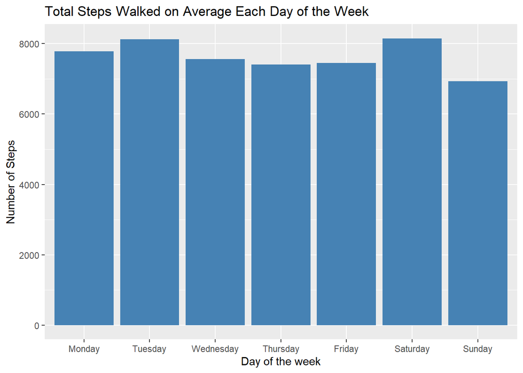

```r
ggplot(aggregate_steps_daily_table, aes(x = weekday, y = Steps)) +
  geom_bar(stat = "identity", fill ="steelblue") +
  labs(title= "Total Steps Walked on Average Each Day of the Week", x = "Day of the week", y="Number of Steps")
```

**Correlation Test**

Let’s test if there is a correlation between day of the week and steps walked!

```r
weekday_activity_table <- weekday_activity_table %>%
mutate(weekday_integer=as.numeric(weekday_activity_table$weekday <-

factor(weekday_activity_table$weekday, levels = c("Monday", "Tuesday", "Wednesday", "Thursday", "Friday", "Saturday", "Sunday"), ordered = TRUE)))


cor.test(weekday_activity_table$Steps, weekday_activity_table$weekday_integer, method = "spearman")
```

```
##
##  Spearman's rank correlation rho
##
## data:  weekday_activity_table$Steps and weekday_activity_table$weekday_integer
## S = 147858263, p-value = 0.03683
## alternative hypothesis: true rho is not equal to 0
## sample estimates:
##         rho
## -0.06810459
```

**Insights**

Thus, we can conclude that the lack of activity is due to personal choices. It is rather that they have a very sedentary living habits.

### 3. Steps vs Calories Analysis

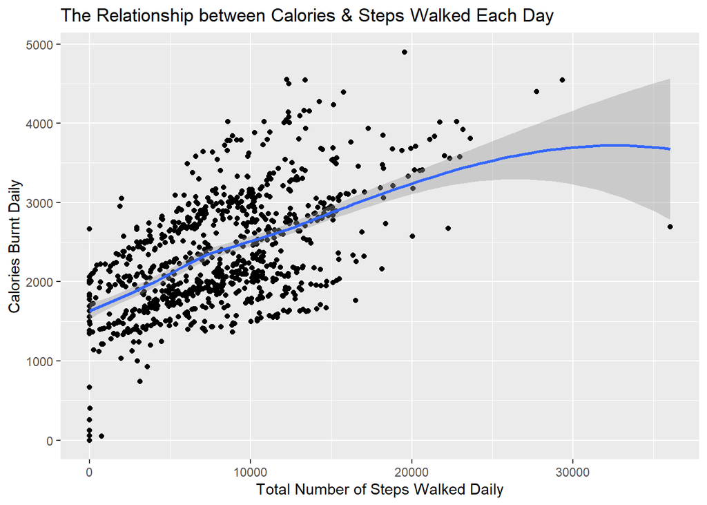

```r
ggplot(data = weekday_activity_table) +
  geom_point(mapping = aes(x = Steps, y = Calories)) +
  geom_jitter(mapping = aes(x = Steps, y = Calories), width
              = 3, size = 1) +
  geom_smooth(mapping = aes(x = Steps, y = Calories),
              method = "loess") +
  labs(x = "Total Number of Steps Walked Daily", y="Calories Burnt Daily", title = "The Relationship between Calories & Steps Walked Each Day" )
```

**Insights** The analysis tells us that more step do lead to more calories burnt. Thus, it is crucial that Bellabeat understand that develop features that encourage more habitual walks.

### 4. Analyze Sleep Data

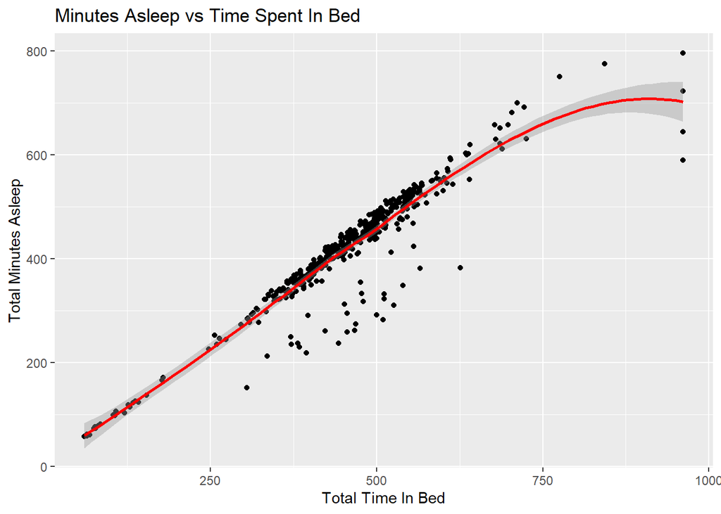

```r
ggplot(data = sleep_day_table_updated) +
  geom_point(mapping = aes(x = TotalTimeInBed, y = TotalMinutesAsleep), color = "Black") +
  geom_smooth(mapping = aes(x = TotalTimeInBed, y = TotalMinutesAsleep), width =0.5, color = "Red") +
  labs(x = "Total Time In Bed", y = "Total Minutes Asleep",title = "Minutes Asleep vs Time Spent In Bed")
```

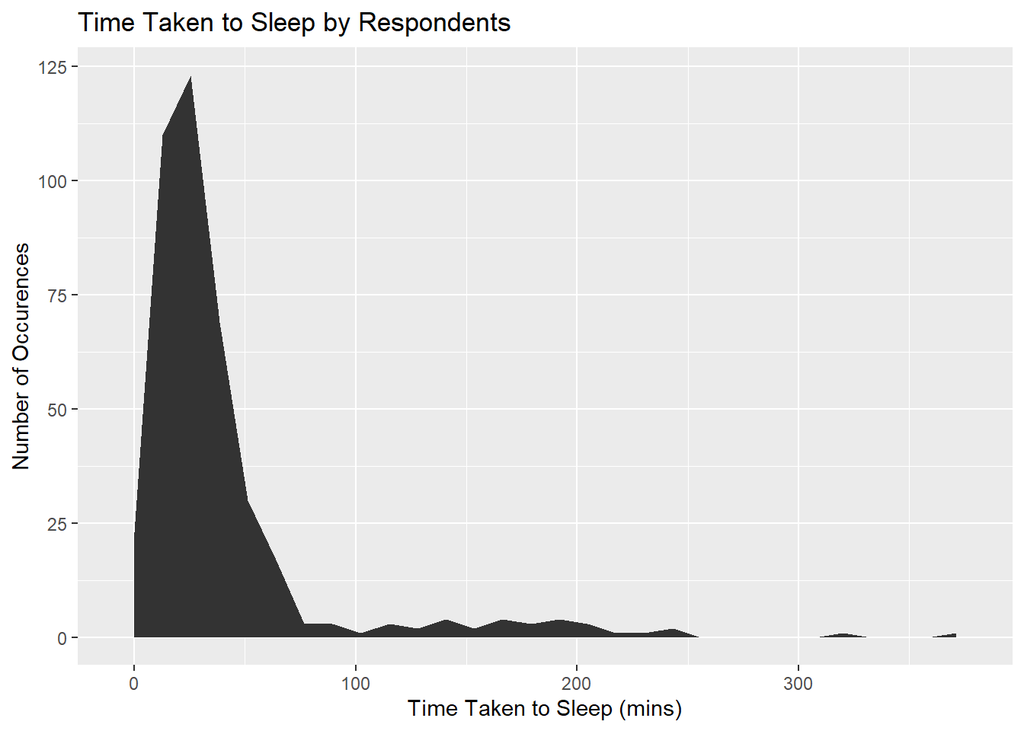

```r
# Analyzing sleep data some more.
ordered_sleep_table_updated <- sleep_day_table_updated %>%
  mutate(time_taken_to_sleep = TotalTimeInBed - TotalMinutesAsleep)

# Now, that we have calculated & formed a new column. Let's plot our data.
time_taken_to_sleep_graph <- ggplot(ordered_sleep_table_updated, aes(x = time_taken_to_sleep)) +
geom_area(stat = "bin", bins = 30) +
labs(x="Time Taken to Sleep (mins)", y="Number of Occurences",
     title="Time Taken to Sleep by Respondents")

#Let's view our graph
time_taken_to_sleep_graph
```

**Insights**

- It is clear through our findings that minutes spent in bed lead to more minutes slept. The participants all seem to have an easier to going to sleep. However, there are a select few who *have trouble falling sleep*. As the first plot demonstrates. The red line indicates how the time asleep should be according to the time in bed changes. The points below the trend line suggest some require longer minutes to fall asleep. The are our outliers.
- Furthermore, the second graph demonstrates further the inability to go to sleep by some participants. Nevertheless, most participants take 0 to 100 minutes falling asleep.
- We will provide recommendations as to how to better serve these customers.

### 5. Analyze Weight Log Data

```r
#Let's Analyze the weight log data, but first let's organize the data.
sorted_weight_log_info <- weight_log_info_updated[order(weight_log_info_updated$BMI),]

#First Create a category
underweight_respondents <- sorted_weight_log_info %>% filter(BMI < 18.5)
overweight_respondents <- sorted_weight_log_info %>% filter(BMI > 24.9)
obese_respondents <- sorted_weight_log_info %>% filter(BMI > 30)

#Let's assess the number unique ID's
noquote("Total Number of Unique Respondents")
```

```
## [1] Total Number of Unique Respondents
```

```r
cat("\n")
```

```r
length(unique(sorted_weight_log_info$Id))
```

```
## [1] 8
```

```r
#Now Let's check the BMI of the respondents
noquote("Total Number of Underweight Respondents")
```

```
## [1] Total Number of Underweight Respondents
```

```r
cat("\n")
```

```r
length(unique(underweight_respondents$Id))
```

```
## [1] 0
```

```r
noquote("Details of underweight respondents")
```

```
## [1] Details of underweight respondents
```

```r
cat("\n")
```

```r
underweight_respondents
```

```
## [1] Id             Date           Time           WeightKg       WeightPounds
## [6] Fat            BMI            IsManualReport LogId
## <0 rows> (or 0-length row.names)
```

```r
cat("\n")
```

```r
noquote("Total Number of Overweight Respondents")
```

```
## [1] Total Number of Overweight Respondents
```

```r
cat("\n")
```

```r
length(unique(overweight_respondents$Id))
```

```
## [1] 5
```

```r
noquote("Details of overweight respondents")
```

```
## [1] Details of overweight respondents
```

```r
cat("\n")
```

```r
overweight_respondents
```

```
##            Id       Date     Time WeightKg WeightPounds Fat   BMI
## 1  8877689391 2016-05-12  6:42:53     84.0     185.1883  NA 25.14
## 2  8877689391 2016-05-04  6:48:22     84.4     186.0702  NA 25.26
## 3  8877689391 2016-04-21  6:50:27     84.5     186.2906  NA 25.29
## 4  8877689391 2016-04-14  6:48:43     84.5     186.2906  NA 25.31
## 5  8877689391 2016-04-13  6:55:00     84.9     187.1725  NA 25.41
## 6  8877689391 2016-04-20  6:44:54     84.9     187.1725  NA 25.41
## 7  8877689391 2016-04-29  6:49:55     84.9     187.1725  NA 25.41
## 8  8877689391 2016-05-03  6:49:41     84.9     187.1725  NA 25.41
## 9  8877689391 2016-05-06  6:43:35     85.0     187.3929  NA 25.44
## 10 8877689391 2016-04-26  6:50:27     85.1     187.6134  NA 25.49
## 11 8877689391 2016-04-28  6:50:03     85.1     187.6134  NA 25.49
## 12 8877689391 2016-04-19  6:39:31     85.3     188.0543  NA 25.53
## 13 8877689391 2016-05-01  8:47:49     85.3     188.0543  NA 25.53
## 14 8877689391 2016-04-25  6:40:16     85.4     188.2748  NA 25.56
```

[output cut: 53 more lines]

```r
cat("\n")
```

```r
noquote("Total Number of Obese Respondents")
```

```
## [1] Total Number of Obese Respondents
```

```r
cat("\n")
```

```r
length(unique(overweight_respondents$Id))
```

```
## [1] 5
```

```r
noquote("Details of obese respondents")
```

```
## [1] Details of obese respondents
```

```r
cat("\n")
```

```r
obese_respondents
```

```
##           Id       Date    Time WeightKg WeightPounds Fat   BMI IsManualReport
## 1 1927972279 2016-04-13 1:08:52    133.5     294.3171  NA 47.54          False
##         LogId
## 1 1.46051e+12
```

*Insights*

According to the *CDC* the average health adult’s **BMI** should be between *18.5 - 24.9*. Link https://www.cdc.gov/healthyweight/assessing/bmi/adult_bmi/index.html.

## Part 6: Act

In this part of the analysis we will *summarize* our finding and provide *high-level recommendations.*

### 1. Summary of Findings.

Throughout this analysis we examined four datasests. Those being daily activity, daily calories, daily sleep, & weight of our participants. We have put those datasets through multiple test in order to get an understanding. Let’s look at each of our analysis.

**a. Daily Activity**

So through our analysis we have been able understand the following things:

The participants as a group averaged a 7,000+ steps per day. This below the recommended 10,000 by medical professionals.

The correlation test between the **Weekday & Steps Taken** was performed. The result revealed that the little to no correlation between the variables. The correlation coefficient being **-0.06810459**.

**Conclusion**

The participants in this group leed a rather sedentary lifestyle. So, our recommendation is going forward to provide customers a challenge based gadgets that better encourages activity.

**b. Daily Calories Table**

**Conclusion**

It is possible to say more Steps lead to more Calories Burnt.

**c. Sleep Data**

Our investigation on the sleep habits of our participants revealed the following:

Most of the participants have an easier time falling asleep.

However, there are a select few whom have **trouble falling asleep**.

Our first test of the data revealed that it took the participants **0 - 100** minutes falling asleep. It also demonstrated our **outliers.**

**Conclusions**

We suggest the Bellabeat marketing team to provide, gadgets to cater to these individuals.

**d. Weight Data**

A look in to our participants weight data revealed that:

Most of the participants were either overweight or obese.

The average *BMI* of the participants being **25.19**.

**Conclusion**

### 2. Recommendation

Bases on our findings what we recommend to the marketing team is:

The data shows the average **Bellabeat”” customers leads a **very low activity** or **sedentary** lifestyle. We suggest that the marketing team develop features that suggest more activities. Suggestions such as *Take the stairs today!*. The device should also notify the user they are below the recommended daily steps which is *10,000*.

The majority of people using **Bellabeat’s smart devices** seem to be **overweight**. Therefore, targeting those customers can be of help. Build features that come with a recommendation of what time to get activities up. Provide **notifications** as to when the customers should engage in more active exercises. They should be encourage to track their *Weight* & *BMI* more closely.

Also, **advertise** to those with dealing with difficulty of falling asleep as well. We recommend the team to develop a sleep routine suggestions.

Through these new features it is possible to improve the life of the customers. In return being able to have a satisfied customers.

From two angles Improve health & then gain health. since most people in america are overweight a more tuned for these majority might increase revenue.